# In-class Exercise Lecture 10

01939418

26/11/2020

## Instruction

- Complete this RMarkdown file and “Knit” the HTML output (saved as **Lecture10_YOUR_CID_NUMBER.html**) and upload to the Hub before the deadline.
- Change the author property in the YAML header above to your CID number.
- Your task is to create static/interactive charts based on 3 different datasets, and refine the charts.

## Plot 1

Examine the `ggplot2::economics` dataset first, and come up with a hypothesis, or an idea for which attributes or patterns to compare. Then, go to [from Data to Viz website](https://www.data-to-viz.com) for an inspiration and recreate a chart using this dataset. Document your thought process below in Markdown.

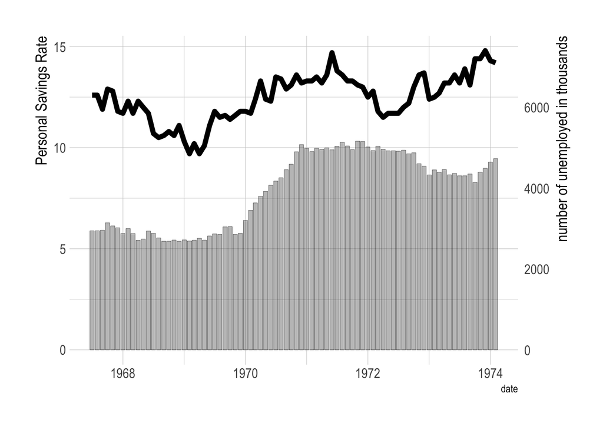

```r
coeff <- 500

# A few constants
temperatureColor <- "#69b3a2"
priceColor <- rgb(0.2, 0.6, 0.9, 1)
ggplot(head(economics, 80), aes(x=date)) +
  geom_bar(aes(y=unemploy/coeff), stat="identity", size=.1, color="black", alpha=.4) +
  geom_line( aes(y=psavert), size=2) +
  scale_y_continuous(
    # Features of the first axis
    name = "Personal Savings Rate",
    # Add a second axis and specify its features
    sec.axis = sec_axis(~.*coeff, name="number of unemployed in thousands")
  ) +
  theme_ipsum() +
  theme(
    axis.title.y = element_text(size=13),
    axis.title.y.right = element_text(size=13)
  )
```

#### Hypothesis

The number of unemployed has a positive correlation with the personal savings rate. That is to say, when the number unemployed increases, the personal savings rate should increase as well, because people are saving more money because they lose the job.

#### Insights

- To comparing the unemployment and personal savings rate, I created a plot with two y-axis to observe the correlation between the two variables.
- When the number of unemployed increased, the positive correlation exist: in 1970, when the number of unemployed increases, the personal savings rate increased as well.
- But the positive correlation does not exist in all circumstance: when the number of unemployed stabilized in 1972, the personal savings rate started to fall. Also, when the number of unemployed decreased in 1973, the personal savings rate fell in turn.

## Plot 2

Examine the `ggplot2::diamonds` dataset first, and come up with a hypothesis, or an idea for which attributes or patterns to compare. Then, create a static `ggplot2` chart of your choice. Then, apply `plotly::ggplotly()` function to convert ggplot object to plotly graph. Document your thought process below in Markdown

```r
diamonds %>%
  group_by(cut) %>%
  summarise(Maxprice = max(price),Minprice = min(price)) %>%
  plot_ly(x = ~Maxprice, y = ~cut, name = "Highest Price", type = 'scatter',mode = "markers", marker = list(color = "blue")) %>%
  add_trace(x = ~Minprice, y = ~cut, name = "Lowest Price",type = 'scatter',mode = "markers", marker = list(color = "pink")) %>%
  layout(xaxis = list(title = "Price"),margin = list(l = 100)) %>%
  ggplotly()
```

[interactive chart not shown]

#### Hypothesis

The lowest price and highest price of diamonds is related to the cut of diamonds.

#### Insights

- To determine whether there is a clear trend that the lowest price of fair diamond is significantly higher than the lowest price of ideal diamond, I draw a Dot Plots for the lowest and highest price of different cut of diamond.
- The lowest price of different cut of diamond are mostly the same.
- The better the cut of diamond, the higher the highest price of diamond. However, the difference is not significant.

## Plot 3

Examine the `ggplot2::txhousing` dataset first, and come up with a hypothesis, or an idea for which attributes or patterns to compare. Then, go to [plotly website](https://plotly.com/r/) for an inspiration and recreate an **interactive** chart using this dataset. Document your thought process below in Markdown.

```r
year_group <- txhousing %>%
  group_by(year)
year_group[is.na(year_group)] <- 0

year_group_by <- year_group %>%
  summarise(sales_sum=sum(sales),listings_sum=sum(listings))
```

```r
plot_ly(year_group_by, x = ~year, y = ~sales_sum, type = 'bar', name = 'Sales Sum') %>%
  add_trace(y = ~listings_sum, name = 'Listings Sum') %>%
  layout(yaxis = list(title = 'Count'), barmode = 'stack')
```

[interactive chart not shown]

#### Hypothesis

The sum values of listings and sum values of sales should follow stable ratio.

#### Insights

- The listings sum fluctuated over the years.
- The Sales sum is mostly stable.
- The sum values of listings and sum values of sales does not have a stable ratio.